# Chapter 7: Comparing a Numerical Variable Across Two Groups

## COMPARING TWO POPULATION MEANS: DEPENDENT SAMPLES (paired t-test)

The hypothesis testing procedures presented in this section should be used when the observations from the two groups being compared are dependent. Whether or not the observations are dependent is determined by how the data are collected. To see this, consider the following example.

### Example 7.3: Diet and Cholesterol (Paired t-test)

Recall, in **Example 7.2**, researchers investigated whether eating corn flakes compared to oat bran had an effect on serum cholesterol levels. Twenty-eight (28) individuals were randomly assigned a diet that included either corn flakes (14 individuals) or oat bran (14 individuals). After two weeks, cholesterol levels (mmol/L) of the participant were recorded.

*But actually what happened was…*

Fourteen (14) individuals were randomly assigned a diet that included either corn flakes or oat bran. After two weeks on the initial diet, serum cholesterol were measured and the participants were then crossed-over to the alternate diet. After two-weeks on the second diet, cholesterol levels were once again recorded.

1. How was the data collected differently from Example 7.2?
2. Are the cholesterol levels of individuals independent across the 28 measurements? Explain.

Since we can match or pair the cholesterol level measurements between the treatment groups, we call this a **paired study design**. These could be paired up by taking measurements on the same observational unit twice or taking measurements on similar observational units (e.g. identical twins, similar fields, etc.). When analyzing the data and making conclusions, we must take this design into consideration or we are violating a key assumption (independent observations *between* groups!).

The data set below shows the data for each participant `ID`. The `CORNLK` column indicates the cholesterol level for that individual on the corn flake diet and the `OATBRAN` column indicates the cholesterol level for that individual on the oat bran diet.

```r
head(cholesterol_data)
```

```
# A tibble: 6 × 4
  ID    CORNFLK OATBRAN CholesterolDiff
  <fct>   <dbl>   <dbl>           <dbl>
1 1        4.61    3.84           0.770
2 2        6.42    5.57           0.85
3 3        5.4     5.85          -0.450
4 4        4.54    4.8           -0.260
5 5        3.98    3.68           0.300
6 6        3.82    2.96           0.86
```

3. What can be said about the Cholesterol of Subject ID #1 as compared to Subject ID #2, for example, regardless of which diet the Cholesterol levels were measured after?

**Big Idea**

For these data, the cholesterol level on the corn flake diet is related to the cholesterol level on the oat bran diet (the two measurements were made on the same person). Thus, these two samples are *dependent*.

In other words, much of the variability in the observations is due to differences between people. So, to control for this variability in cholesterol levels from person to person (which will help us isolate the effect of diet), we will work with the **DIFFERENCES** on each subject, instead. This will remove the structure of dependence between the corn flake and oat bran groups and will control for the fact that some people, in general, tend to have higher (or lower) cholesterol levels than others.

4. What does the `CholesterolDiff` column represent? Why does this calculation make sense?
5. What does a positive difference of 0.77 indicate?
6. What does a negative difference of -0.45 indicate?

A histogram of the differences in cholesterol levels for the 14 individuals and a table of summary statistics are shown below.

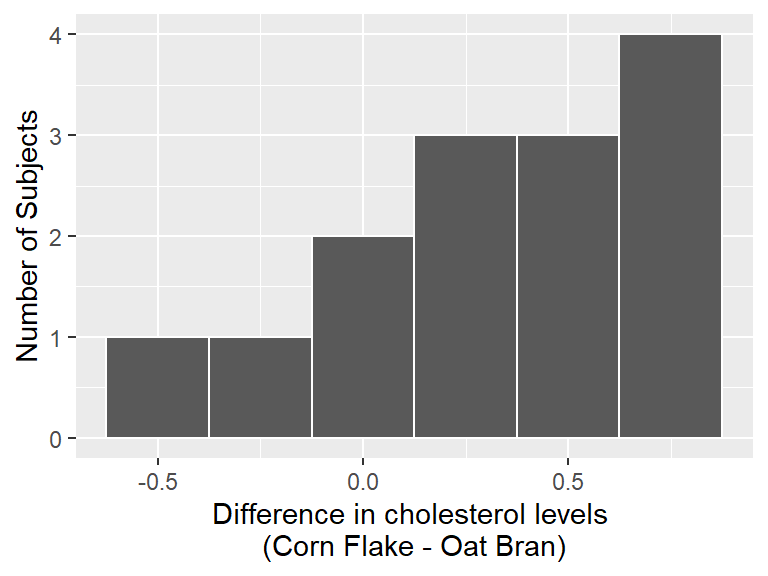

Summary statistics for the difference in cholesterol levels between the corn flake diet and oat bran diet are given below:

```r
favstats(~ CholesterolDiff, data = cholesterol_data)
```

```
   min    Q1 median    Q3  max      mean        sd  n missing
 -0.45 0.115   0.36 0.695 0.86 0.3628571 0.4059638 14       0
```

7. What is the mean of the differences for the 14 subjects? Interpret this value. Does this value seem familiar?
8. If cereal diet had *no effect* on cholesterol levels, what would you expect the mean of these differences to be?

**Big Idea: paired t-test**

Note that these differences are represented by a single column of data. So, instead of viewing this as a problem involving a categorical predictor and a numerical response, you could view this as a problem involving a single numerical variable – the differences! Therefore, the hypothesis testing procedure is exactly the same as the procedure for testing a single population mean we discussed in Chapter 6.

That is, the parameter of interest is the true population mean of the differences which we will represent by $\mu_\text{difference}$.

- Our best estimate for this parameter is the sample mean of the observed differences. We’ll call this quantity $\bar x_\text{difference}$.
- The sample standard deviation of the differences will be denoted by $s_\text{difference}$.

We can carry out the hypothesis test as follows to determine whether cholesterol levels of all adults tend to *differ* between cereal diets.

**Research Question** Researchers are still interested in whether eating corn flakes compared to oat bran had an effect on serum cholesterol levels.

9. Write the parameter of interest in words.
10. Set up the null and alternative hypotheses in words and symbols.
11. Calculate the T test-statistic:

$$T = \frac{\bar x_\text{difference} - \mu_\text{difference}}{s_\text{difference}/\sqrt{n}}$$

12. Using the t-distribution provided below, show how you would estimate the p-value.

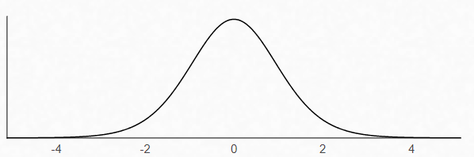

Similar to Chapter 6, the R code below can be used to conduct the paired t-test:

```r
t_test(x = cholesterol_data,
       response = CholesterolDiff,
       mu = 0,
       alternative = "two-sided")
```

```
# A tibble: 1 × 7
  statistic  t_df p_value alternative estimate lower_ci upper_ci
      <dbl> <dbl>   <dbl> <chr>          <dbl>    <dbl>    <dbl>
1      3.34    13 0.00528 two.sided      0.363    0.128    0.597
```

13. State a conclusion in context of the study. Make sure to include proper evidence.
14. How does your conclusion differ from your conclusion in Example 7.2 when we assumed independent samples?
15. Can we conclude that the diet *caused* the change? Explain.

**Checking the Normality Assumption (CLT) for a Paired t-test**

Recall that for the t-test to be valid, at least one of the following conditions must be met:

- Either the sample size is sufficiently large (greater than 30 or so), or
- The distribution of the observed data is approximately normal (which would indicate that the population is normally distributed so that the Central Limit Theorem would apply even with a small sample size)
16. Does the t-test appear to be a valid approach for testing this research question? Justify your reasoning.
17. Using the formula for confidence intervals for single numerical variables from Chapter 6 and the t-quantile provided below, calculate the 90% confidence interval.

```r
qt(0.95, 13)
```

```
[1] 1.770933
```

$$\bar x_\text{difference} \pm \text{t-quantile}\big(\frac{s_\text{difference}}{\sqrt{n}}\big)=$$

18. Where does 0 fall within the confidence interval? Why does this make sense?